# Risk Factor Analysis

## Outcome Variable

**Outcome Variable:** y_rate_len

## Predictor Variables

**Intervention Variable:** predfeed3

**Adjustment Set:**

- arm
- sex
- month
- brthmon
- W_mage
- meducyrs
- feducyrs
- hhwealth_quart
- hfoodsec
- W_mhtcm
- W_mwtkg
- W_mbmi
- vagbrth
- W_gagebrth
- W_birthwt
- W_birthlen
- W_nrooms
- W_nchldlt5
- W_parity
- impfloor
- impsan
- safeh20
- delta_W_mage
- delta_meducyrs
- delta_feducyrs
- delta_hhwealth_quart
- delta_hfoodsec
- delta_W_mhtcm
- delta_W_mwtkg
- delta_W_mbmi
- delta_vagbrth
- delta_W_gagebrth
- delta_W_birthwt
- delta_W_birthlen
- delta_W_nrooms
- delta_W_nchldlt5
- delta_W_parity
- delta_impfloor
- delta_impsan
- delta_safeh20

## Stratifying Variables

The analysis was stratified on these variable(s):

- agecat
- studyid
- country

## Data Summary

| agecat | studyid | country | predfeed3 | n_cell | n |
| --- | --- | --- | --- | --- | --- |
| 0-3 months | EE | PAKISTAN | 1 | 31 | 31 |
| 0-3 months | EE | PAKISTAN | 0 | 0 | 31 |
| 0-3 months | GMS-Nepal | NEPAL | 1 | 378 | 456 |
| 0-3 months | GMS-Nepal | NEPAL | 0 | 78 | 456 |
| 0-3 months | JiVitA-3 | BANGLADESH | 1 | 10705 | 11852 |
| 0-3 months | JiVitA-3 | BANGLADESH | 0 | 1147 | 11852 |
| 0-3 months | JiVitA-4 | BANGLADESH | 1 | 111 | 121 |
| 0-3 months | JiVitA-4 | BANGLADESH | 0 | 10 | 121 |
| 0-3 months | MAL-ED | BANGLADESH | 1 | 193 | 237 |
| 0-3 months | MAL-ED | BANGLADESH | 0 | 44 | 237 |
| 0-3 months | MAL-ED | BRAZIL | 1 | 73 | 147 |
| 0-3 months | MAL-ED | BRAZIL | 0 | 74 | 147 |
| 0-3 months | MAL-ED | INDIA | 1 | 113 | 164 |
| 0-3 months | MAL-ED | INDIA | 0 | 51 | 164 |
| 0-3 months | MAL-ED | NEPAL | 1 | 81 | 153 |
| 0-3 months | MAL-ED | NEPAL | 0 | 72 | 153 |
| 0-3 months | MAL-ED | PERU | 1 | 168 | 262 |
| 0-3 months | MAL-ED | PERU | 0 | 94 | 262 |
| 0-3 months | MAL-ED | SOUTH AFRICA | 1 | 58 | 203 |
| 0-3 months | MAL-ED | SOUTH AFRICA | 0 | 145 | 203 |
| 0-3 months | MAL-ED | TANZANIA, UNITED REPUBLIC OF | 1 | 57 | 197 |
| 0-3 months | MAL-ED | TANZANIA, UNITED REPUBLIC OF | 0 | 140 | 197 |
| 3-6 months | EE | PAKISTAN | 1 | 31 | 31 |
| 3-6 months | EE | PAKISTAN | 0 | 0 | 31 |
| 3-6 months | GMS-Nepal | NEPAL | 1 | 350 | 420 |
| 3-6 months | GMS-Nepal | NEPAL | 0 | 70 | 420 |
| 3-6 months | JiVitA-3 | BANGLADESH | 1 | 6478 | 7103 |
| 3-6 months | JiVitA-3 | BANGLADESH | 0 | 625 | 7103 |
| 3-6 months | JiVitA-4 | BANGLADESH | 1 | 21 | 21 |
| 3-6 months | JiVitA-4 | BANGLADESH | 0 | 0 | 21 |

[output cut: 130 more lines]

The following strata were considered:

- agecat: 0-3 months, studyid: EE, country: PAKISTAN
- agecat: 0-3 months, studyid: GMS-Nepal, country: NEPAL
- agecat: 0-3 months, studyid: JiVitA-3, country: BANGLADESH
- agecat: 0-3 months, studyid: JiVitA-4, country: BANGLADESH
- agecat: 0-3 months, studyid: MAL-ED, country: BANGLADESH
- agecat: 0-3 months, studyid: MAL-ED, country: BRAZIL
- agecat: 0-3 months, studyid: MAL-ED, country: INDIA
- agecat: 0-3 months, studyid: MAL-ED, country: NEPAL
- agecat: 0-3 months, studyid: MAL-ED, country: PERU
- agecat: 0-3 months, studyid: MAL-ED, country: SOUTH AFRICA
- agecat: 0-3 months, studyid: MAL-ED, country: TANZANIA, UNITED REPUBLIC OF
- agecat: 12-15 months, studyid: EE, country: PAKISTAN
- agecat: 12-15 months, studyid: GMS-Nepal, country: NEPAL
- agecat: 12-15 months, studyid: JiVitA-4, country: BANGLADESH
- agecat: 12-15 months, studyid: MAL-ED, country: BANGLADESH
- agecat: 12-15 months, studyid: MAL-ED, country: BRAZIL
- agecat: 12-15 months, studyid: MAL-ED, country: INDIA
- agecat: 12-15 months, studyid: MAL-ED, country: NEPAL
- agecat: 12-15 months, studyid: MAL-ED, country: PERU
- agecat: 12-15 months, studyid: MAL-ED, country: SOUTH AFRICA
- agecat: 12-15 months, studyid: MAL-ED, country: TANZANIA, UNITED REPUBLIC OF
- agecat: 15-18 months, studyid: EE, country: PAKISTAN
- agecat: 15-18 months, studyid: GMS-Nepal, country: NEPAL
- agecat: 15-18 months, studyid: JiVitA-4, country: BANGLADESH
- agecat: 15-18 months, studyid: MAL-ED, country: BANGLADESH
- agecat: 15-18 months, studyid: MAL-ED, country: BRAZIL
- agecat: 15-18 months, studyid: MAL-ED, country: INDIA
- agecat: 15-18 months, studyid: MAL-ED, country: NEPAL
- agecat: 15-18 months, studyid: MAL-ED, country: PERU
- agecat: 15-18 months, studyid: MAL-ED, country: SOUTH AFRICA
- agecat: 15-18 months, studyid: MAL-ED, country: TANZANIA, UNITED REPUBLIC OF
- agecat: 18-21 months, studyid: EE, country: PAKISTAN
- agecat: 18-21 months, studyid: GMS-Nepal, country: NEPAL
- agecat: 18-21 months, studyid: MAL-ED, country: BANGLADESH
- agecat: 18-21 months, studyid: MAL-ED, country: BRAZIL
- agecat: 18-21 months, studyid: MAL-ED, country: INDIA
- agecat: 18-21 months, studyid: MAL-ED, country: NEPAL
- agecat: 18-21 months, studyid: MAL-ED, country: PERU
- agecat: 18-21 months, studyid: MAL-ED, country: SOUTH AFRICA
- agecat: 18-21 months, studyid: MAL-ED, country: TANZANIA, UNITED REPUBLIC OF
- agecat: 21-24 months, studyid: EE, country: PAKISTAN
- agecat: 21-24 months, studyid: GMS-Nepal, country: NEPAL
- agecat: 21-24 months, studyid: MAL-ED, country: BANGLADESH
- agecat: 21-24 months, studyid: MAL-ED, country: BRAZIL
- agecat: 21-24 months, studyid: MAL-ED, country: INDIA
- agecat: 21-24 months, studyid: MAL-ED, country: NEPAL
- agecat: 21-24 months, studyid: MAL-ED, country: PERU
- agecat: 21-24 months, studyid: MAL-ED, country: SOUTH AFRICA
- agecat: 21-24 months, studyid: MAL-ED, country: TANZANIA, UNITED REPUBLIC OF
- agecat: 3-6 months, studyid: EE, country: PAKISTAN
- agecat: 3-6 months, studyid: GMS-Nepal, country: NEPAL
- agecat: 3-6 months, studyid: JiVitA-3, country: BANGLADESH
- agecat: 3-6 months, studyid: JiVitA-4, country: BANGLADESH
- agecat: 3-6 months, studyid: MAL-ED, country: BANGLADESH
- agecat: 3-6 months, studyid: MAL-ED, country: BRAZIL
- agecat: 3-6 months, studyid: MAL-ED, country: INDIA
- agecat: 3-6 months, studyid: MAL-ED, country: NEPAL
- agecat: 3-6 months, studyid: MAL-ED, country: PERU
- agecat: 3-6 months, studyid: MAL-ED, country: SOUTH AFRICA
- agecat: 3-6 months, studyid: MAL-ED, country: TANZANIA, UNITED REPUBLIC OF
- agecat: 6-9 months, studyid: EE, country: PAKISTAN
- agecat: 6-9 months, studyid: GMS-Nepal, country: NEPAL
- agecat: 6-9 months, studyid: JiVitA-4, country: BANGLADESH
- agecat: 6-9 months, studyid: MAL-ED, country: BANGLADESH
- agecat: 6-9 months, studyid: MAL-ED, country: BRAZIL
- agecat: 6-9 months, studyid: MAL-ED, country: INDIA
- agecat: 6-9 months, studyid: MAL-ED, country: NEPAL
- agecat: 6-9 months, studyid: MAL-ED, country: PERU
- agecat: 6-9 months, studyid: MAL-ED, country: SOUTH AFRICA
- agecat: 6-9 months, studyid: MAL-ED, country: TANZANIA, UNITED REPUBLIC OF
- agecat: 9-12 months, studyid: EE, country: PAKISTAN
- agecat: 9-12 months, studyid: GMS-Nepal, country: NEPAL
- agecat: 9-12 months, studyid: JiVitA-4, country: BANGLADESH
- agecat: 9-12 months, studyid: MAL-ED, country: BANGLADESH
- agecat: 9-12 months, studyid: MAL-ED, country: BRAZIL
- agecat: 9-12 months, studyid: MAL-ED, country: INDIA
- agecat: 9-12 months, studyid: MAL-ED, country: NEPAL
- agecat: 9-12 months, studyid: MAL-ED, country: PERU
- agecat: 9-12 months, studyid: MAL-ED, country: SOUTH AFRICA
- agecat: 9-12 months, studyid: MAL-ED, country: TANZANIA, UNITED REPUBLIC OF

### Dropped Strata

- agecat: 0-3 months, studyid: EE, country: PAKISTAN
- agecat: 3-6 months, studyid: EE, country: PAKISTAN
- agecat: 3-6 months, studyid: JiVitA-4, country: BANGLADESH
- agecat: 6-9 months, studyid: EE, country: PAKISTAN
- agecat: 6-9 months, studyid: JiVitA-4, country: BANGLADESH
- agecat: 9-12 months, studyid: EE, country: PAKISTAN
- agecat: 12-15 months, studyid: EE, country: PAKISTAN
- agecat: 15-18 months, studyid: EE, country: PAKISTAN
- agecat: 18-21 months, studyid: EE, country: PAKISTAN
- agecat: 21-24 months, studyid: EE, country: PAKISTAN

## Methods Detail

We’re interested in the causal parameters $E[Y_a]$ for all values of $a \in \mathcal{A}$. These parameters represent the mean outcome if, possibly contrary to fact, we intervened to set all units to have $A=a$. Under the randomization and positivity assumptions, these are identified by the statistical parameters $\psi_a=E_W[E_{Y|A,W}(Y|A=a,W)]$. In addition, we’re interested in the mean of $Y$, $E[Y]$ under no intervention (the observed mean). We will estimate these parameters by using SuperLearner to fit the relevant likelihood factors – $E_{Y|A,W}(Y|A=a,W)$ and $p(A=a|W)$, and then updating our likelihood fit using a joint TMLE.

For unadjusted analyses ($W=\{\}$), initial likelihoods were estimated using Lrnr_glm to estimate the simple $E(Y|A)$ and Lrnr_mean to estimate $p(A)$. For adjusted analyses, a small library containing Lrnr_glmnet, Lrnr_xgboost, and Lrnr_mean was used.

Having estimated these parameters, we will then use the delta method to estimate relative risks and attributable risks relative to a prespecified baseline level of $A$.

# Results Detail

## Results Plots

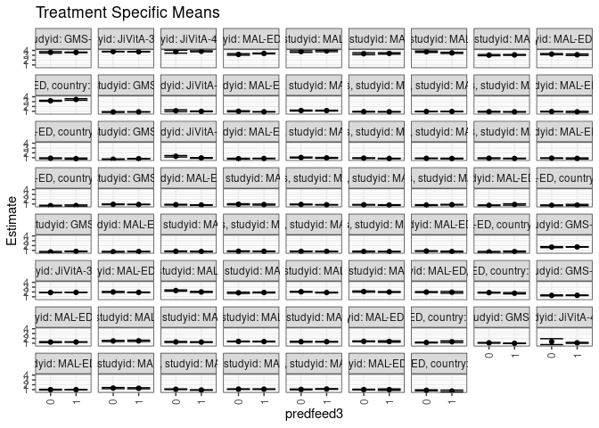

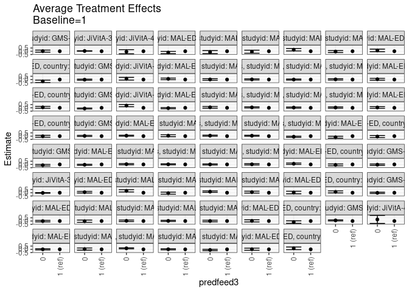

[figure not shown]

## Results Table

### Parameter: TSM

| agecat | studyid | country | intervention_level | baseline_level | estimate | ci_lower | ci_upper |
| --- | --- | --- | --- | --- | --- | --- | --- |
| 0-3 months | GMS-Nepal | NEPAL | 1 | NA | 3.5855096 | 3.5268514 | 3.6441677 |
| 0-3 months | GMS-Nepal | NEPAL | 0 | NA | 3.6012103 | 3.4578268 | 3.7445937 |
| 0-3 months | JiVitA-3 | BANGLADESH | 1 | NA | 3.7221851 | 3.7090524 | 3.7353179 |
| 0-3 months | JiVitA-3 | BANGLADESH | 0 | NA | 3.7602494 | 3.7261994 | 3.7942993 |
| 0-3 months | JiVitA-4 | BANGLADESH | 1 | NA | 3.8140214 | 3.7118381 | 3.9162048 |
| 0-3 months | JiVitA-4 | BANGLADESH | 0 | NA | 3.7379110 | 3.4347246 | 4.0410974 |
| 0-3 months | MAL-ED | BANGLADESH | 1 | NA | 3.3711754 | 3.2986109 | 3.4437399 |
| 0-3 months | MAL-ED | BANGLADESH | 0 | NA | 3.1701229 | 3.0113996 | 3.3288462 |
| 0-3 months | MAL-ED | BRAZIL | 1 | NA | 3.8924301 | 3.7357049 | 4.0491553 |
| 0-3 months | MAL-ED | BRAZIL | 0 | NA | 3.7606334 | 3.5885424 | 3.9327244 |
| 0-3 months | MAL-ED | INDIA | 1 | NA | 3.3872180 | 3.2501553 | 3.5242806 |
| 0-3 months | MAL-ED | INDIA | 0 | NA | 3.3145720 | 3.1242043 | 3.5049396 |
| 0-3 months | MAL-ED | NEPAL | 1 | NA | 3.4882231 | 3.3680429 | 3.6084034 |
| 0-3 months | MAL-ED | NEPAL | 0 | NA | 3.7216881 | 3.5819308 | 3.8614455 |
| 0-3 months | MAL-ED | PERU | 1 | NA | 3.0713249 | 2.9896662 | 3.1529837 |
| 0-3 months | MAL-ED | PERU | 0 | NA | 3.0207483 | 2.8950712 | 3.1464254 |
| 0-3 months | MAL-ED | SOUTH AFRICA | 1 | NA | 3.1040548 | 2.9517779 | 3.2563318 |
| 0-3 months | MAL-ED | SOUTH AFRICA | 0 | NA | 3.2331846 | 3.1101249 | 3.3562443 |
| 0-3 months | MAL-ED | TANZANIA, UNITED REPUBLIC OF | 1 | NA | 3.4464601 | 3.2897633 | 3.6031569 |
| 0-3 months | MAL-ED | TANZANIA, UNITED REPUBLIC OF | 0 | NA | 3.1729705 | 3.0754337 | 3.2705073 |
| 3-6 months | GMS-Nepal | NEPAL | 1 | NA | 1.7270253 | 1.6816337 | 1.7724168 |
| 3-6 months | GMS-Nepal | NEPAL | 0 | NA | 1.6892010 | 1.5902748 | 1.7881273 |
| 3-6 months | JiVitA-3 | BANGLADESH | 1 | NA | 1.9191285 | 1.9049056 | 1.9333514 |
| 3-6 months | JiVitA-3 | BANGLADESH | 0 | NA | 1.8906775 | 1.8479580 | 1.9333971 |
| 3-6 months | MAL-ED | BANGLADESH | 1 | NA | 1.9216234 | 1.8663305 | 1.9769164 |
| 3-6 months | MAL-ED | BANGLADESH | 0 | NA | 2.0038784 | 1.8867749 | 2.1209819 |
| 3-6 months | MAL-ED | BRAZIL | 1 | NA | 2.0082925 | 1.8932598 | 2.1233251 |
| 3-6 months | MAL-ED | BRAZIL | 0 | NA | 2.2993587 | 2.1724283 | 2.4262890 |
| 3-6 months | MAL-ED | INDIA | 1 | NA | 1.8968388 | 1.8155602 | 1.9781174 |
| 3-6 months | MAL-ED | INDIA | 0 | NA | 1.8299555 | 1.6952616 | 1.9646494 |

[output cut: 110 more lines]

### Parameter: E(Y)

| agecat | studyid | country | intervention_level | baseline_level | estimate | ci_lower | ci_upper |
| --- | --- | --- | --- | --- | --- | --- | --- |
| 0-3 months | GMS-Nepal | NEPAL | NA | NA | 3.5832888 | 3.5291425 | 3.6374351 |
| 0-3 months | JiVitA-3 | BANGLADESH | NA | NA | 3.7257309 | 3.7129962 | 3.7384655 |
| 0-3 months | JiVitA-4 | BANGLADESH | NA | NA | 3.7971810 | 3.7001091 | 3.8942529 |
| 0-3 months | MAL-ED | BANGLADESH | NA | NA | 3.3300100 | 3.2632400 | 3.3967800 |
| 0-3 months | MAL-ED | BRAZIL | NA | NA | 3.8333086 | 3.7172183 | 3.9493989 |
| 0-3 months | MAL-ED | INDIA | NA | NA | 3.3581259 | 3.2511263 | 3.4651254 |
| 0-3 months | MAL-ED | NEPAL | NA | NA | 3.6149130 | 3.5218465 | 3.7079794 |
| 0-3 months | MAL-ED | PERU | NA | NA | 3.0514630 | 2.9842485 | 3.1186774 |
| 0-3 months | MAL-ED | SOUTH AFRICA | NA | NA | 3.1964081 | 3.0976125 | 3.2952037 |
| 0-3 months | MAL-ED | TANZANIA, UNITED REPUBLIC OF | NA | NA | 3.2460048 | 3.1627741 | 3.3292354 |
| 3-6 months | GMS-Nepal | NEPAL | NA | NA | 1.7175472 | 1.6762113 | 1.7588831 |
| 3-6 months | JiVitA-3 | BANGLADESH | NA | NA | 1.9166214 | 1.9029983 | 1.9302445 |
| 3-6 months | MAL-ED | BANGLADESH | NA | NA | 1.9360220 | 1.8863911 | 1.9856528 |
| 3-6 months | MAL-ED | BRAZIL | NA | NA | 2.1610058 | 2.0768189 | 2.2451928 |
| 3-6 months | MAL-ED | INDIA | NA | NA | 1.8774058 | 1.8092128 | 1.9455987 |
| 3-6 months | MAL-ED | NEPAL | NA | NA | 1.9604886 | 1.9037186 | 2.0172585 |
| 3-6 months | MAL-ED | PERU | NA | NA | 2.0146923 | 1.9480408 | 2.0813438 |
| 3-6 months | MAL-ED | SOUTH AFRICA | NA | NA | 1.9673270 | 1.8846989 | 2.0499551 |
| 3-6 months | MAL-ED | TANZANIA, UNITED REPUBLIC OF | NA | NA | 1.8384078 | 1.7678309 | 1.9089846 |
| 6-9 months | GMS-Nepal | NEPAL | NA | NA | 1.3149164 | 1.2666599 | 1.3631729 |
| 6-9 months | MAL-ED | BANGLADESH | NA | NA | 1.2426951 | 1.2021480 | 1.2832422 |
| 6-9 months | MAL-ED | BRAZIL | NA | NA | 1.4793615 | 1.3932814 | 1.5654415 |
| 6-9 months | MAL-ED | INDIA | NA | NA | 1.2410939 | 1.1870908 | 1.2950970 |
| 6-9 months | MAL-ED | NEPAL | NA | NA | 1.3593977 | 1.3145109 | 1.4042846 |
| 6-9 months | MAL-ED | PERU | NA | NA | 1.3181643 | 1.2633979 | 1.3729307 |
| 6-9 months | MAL-ED | SOUTH AFRICA | NA | NA | 1.3866251 | 1.3204306 | 1.4528196 |
| 6-9 months | MAL-ED | TANZANIA, UNITED REPUBLIC OF | NA | NA | 1.1862735 | 1.1092792 | 1.2632679 |
| 9-12 months | GMS-Nepal | NEPAL | NA | NA | 0.9981577 | 0.9587526 | 1.0375629 |
| 9-12 months | JiVitA-4 | BANGLADESH | NA | NA | 1.0827638 | 1.0008916 | 1.1646360 |
| 9-12 months | MAL-ED | BANGLADESH | NA | NA | 0.9927203 | 0.9534705 | 1.0319702 |
| 9-12 months | MAL-ED | BRAZIL | NA | NA | 1.2871495 | 1.2069822 | 1.3673169 |
| 9-12 months | MAL-ED | INDIA | NA | NA | 0.9664571 | 0.9272553 | 1.0056589 |
| 9-12 months | MAL-ED | NEPAL | NA | NA | 1.0863279 | 1.0443920 | 1.1282637 |
| 9-12 months | MAL-ED | PERU | NA | NA | 1.0996556 | 1.0484043 | 1.1509069 |
| 9-12 months | MAL-ED | SOUTH AFRICA | NA | NA | 0.9974431 | 0.9321487 | 1.0627375 |
| 9-12 months | MAL-ED | TANZANIA, UNITED REPUBLIC OF | NA | NA | 0.8135761 | 0.7280408 | 0.8991114 |
| 12-15 months | GMS-Nepal | NEPAL | NA | NA | 0.8703223 | 0.8418462 | 0.8987983 |
| 12-15 months | JiVitA-4 | BANGLADESH | NA | NA | 0.9942404 | 0.9259295 | 1.0625513 |
| 12-15 months | MAL-ED | BANGLADESH | NA | NA | 0.9168218 | 0.8756400 | 0.9580036 |
| 12-15 months | MAL-ED | BRAZIL | NA | NA | 1.1479969 | 1.0880713 | 1.2079226 |
| 12-15 months | MAL-ED | INDIA | NA | NA | 0.9027484 | 0.8605827 | 0.9449141 |
| 12-15 months | MAL-ED | NEPAL | NA | NA | 0.9510803 | 0.9108264 | 0.9913342 |
| 12-15 months | MAL-ED | PERU | NA | NA | 0.8899324 | 0.8436019 | 0.9362629 |
| 12-15 months | MAL-ED | SOUTH AFRICA | NA | NA | 0.9200282 | 0.8606688 | 0.9793876 |
| 12-15 months | MAL-ED | TANZANIA, UNITED REPUBLIC OF | NA | NA | 0.8603058 | 0.7910045 | 0.9296071 |
| 15-18 months | GMS-Nepal | NEPAL | NA | NA | 0.7714871 | 0.7347479 | 0.8082263 |
| 15-18 months | JiVitA-4 | BANGLADESH | NA | NA | 0.9624250 | 0.8894872 | 1.0353628 |
| 15-18 months | MAL-ED | BANGLADESH | NA | NA | 0.8229575 | 0.7855057 | 0.8604093 |
| 15-18 months | MAL-ED | BRAZIL | NA | NA | 0.9818884 | 0.9203285 | 1.0434482 |
| 15-18 months | MAL-ED | INDIA | NA | NA | 0.8524809 | 0.8141426 | 0.8908193 |
| 15-18 months | MAL-ED | NEPAL | NA | NA | 0.8379671 | 0.7952249 | 0.8807093 |
| 15-18 months | MAL-ED | PERU | NA | NA | 0.8524194 | 0.8100116 | 0.8948273 |
| 15-18 months | MAL-ED | SOUTH AFRICA | NA | NA | 0.8824996 | 0.8291590 | 0.9358403 |
| 15-18 months | MAL-ED | TANZANIA, UNITED REPUBLIC OF | NA | NA | 0.6765672 | 0.6111365 | 0.7419980 |
| 18-21 months | GMS-Nepal | NEPAL | NA | NA | 0.9164610 | 0.8758269 | 0.9570951 |
| 18-21 months | MAL-ED | BANGLADESH | NA | NA | 0.8119236 | 0.7768456 | 0.8470016 |
| 18-21 months | MAL-ED | BRAZIL | NA | NA | 0.9218418 | 0.8499673 | 0.9937164 |
| 18-21 months | MAL-ED | INDIA | NA | NA | 0.8718128 | 0.8338464 | 0.9097793 |
| 18-21 months | MAL-ED | NEPAL | NA | NA | 0.8188898 | 0.7796721 | 0.8581075 |
| 18-21 months | MAL-ED | PERU | NA | NA | 0.8436364 | 0.7988407 | 0.8884321 |
| 18-21 months | MAL-ED | SOUTH AFRICA | NA | NA | 0.7825058 | 0.7256746 | 0.8393371 |
| 18-21 months | MAL-ED | TANZANIA, UNITED REPUBLIC OF | NA | NA | 0.7427314 | 0.6697155 | 0.8157473 |
| 21-24 months | GMS-Nepal | NEPAL | NA | NA | 0.7890401 | 0.7373935 | 0.8406867 |
| 21-24 months | MAL-ED | BANGLADESH | NA | NA | 0.7650086 | 0.7291204 | 0.8008969 |
| 21-24 months | MAL-ED | BRAZIL | NA | NA | 0.7910255 | 0.7450530 | 0.8369980 |
| 21-24 months | MAL-ED | INDIA | NA | NA | 0.8277879 | 0.7947160 | 0.8608598 |
| 21-24 months | MAL-ED | NEPAL | NA | NA | 0.7874809 | 0.7457868 | 0.8291749 |
| 21-24 months | MAL-ED | PERU | NA | NA | 0.7633557 | 0.7160871 | 0.8106244 |
| 21-24 months | MAL-ED | SOUTH AFRICA | NA | NA | 0.8419384 | 0.7887410 | 0.8951359 |
| 21-24 months | MAL-ED | TANZANIA, UNITED REPUBLIC OF | NA | NA | 0.7195266 | 0.6482537 | 0.7907995 |

### Parameter: ATE

| agecat | studyid | country | intervention_level | baseline_level | estimate | ci_lower | ci_upper |
| --- | --- | --- | --- | --- | --- | --- | --- |
| 0-3 months | GMS-Nepal | NEPAL | 1 | 1 | 0.0000000 | 0.0000000 | 0.0000000 |
| 0-3 months | GMS-Nepal | NEPAL | 0 | 1 | 0.0157007 | -0.1395560 | 0.1709573 |
| 0-3 months | JiVitA-3 | BANGLADESH | 1 | 1 | 0.0000000 | 0.0000000 | 0.0000000 |
| 0-3 months | JiVitA-3 | BANGLADESH | 0 | 1 | 0.0380642 | 0.0031675 | 0.0729609 |
| 0-3 months | JiVitA-4 | BANGLADESH | 1 | 1 | 0.0000000 | 0.0000000 | 0.0000000 |
| 0-3 months | JiVitA-4 | BANGLADESH | 0 | 1 | -0.0761105 | -0.3953517 | 0.2431307 |
| 0-3 months | MAL-ED | BANGLADESH | 1 | 1 | 0.0000000 | 0.0000000 | 0.0000000 |
| 0-3 months | MAL-ED | BANGLADESH | 0 | 1 | -0.2010525 | -0.3751723 | -0.0269327 |
| 0-3 months | MAL-ED | BRAZIL | 1 | 1 | 0.0000000 | 0.0000000 | 0.0000000 |
| 0-3 months | MAL-ED | BRAZIL | 0 | 1 | -0.1317967 | -0.3652546 | 0.1016612 |
| 0-3 months | MAL-ED | INDIA | 1 | 1 | 0.0000000 | 0.0000000 | 0.0000000 |
| 0-3 months | MAL-ED | INDIA | 0 | 1 | -0.0726460 | -0.3076917 | 0.1623997 |
| 0-3 months | MAL-ED | NEPAL | 1 | 1 | 0.0000000 | 0.0000000 | 0.0000000 |
| 0-3 months | MAL-ED | NEPAL | 0 | 1 | 0.2334650 | 0.0492393 | 0.4176907 |
| 0-3 months | MAL-ED | PERU | 1 | 1 | 0.0000000 | 0.0000000 | 0.0000000 |
| 0-3 months | MAL-ED | PERU | 0 | 1 | -0.0505766 | -0.2043474 | 0.1031941 |
| 0-3 months | MAL-ED | SOUTH AFRICA | 1 | 1 | 0.0000000 | 0.0000000 | 0.0000000 |
| 0-3 months | MAL-ED | SOUTH AFRICA | 0 | 1 | 0.1291297 | -0.0673712 | 0.3256307 |
| 0-3 months | MAL-ED | TANZANIA, UNITED REPUBLIC OF | 1 | 1 | 0.0000000 | 0.0000000 | 0.0000000 |
| 0-3 months | MAL-ED | TANZANIA, UNITED REPUBLIC OF | 0 | 1 | -0.2734896 | -0.4582096 | -0.0887696 |
| 3-6 months | GMS-Nepal | NEPAL | 1 | 1 | 0.0000000 | 0.0000000 | 0.0000000 |
| 3-6 months | GMS-Nepal | NEPAL | 0 | 1 | -0.0378242 | -0.1463570 | 0.0707085 |
| 3-6 months | JiVitA-3 | BANGLADESH | 1 | 1 | 0.0000000 | 0.0000000 | 0.0000000 |
| 3-6 months | JiVitA-3 | BANGLADESH | 0 | 1 | -0.0284510 | -0.0730194 | 0.0161175 |
| 3-6 months | MAL-ED | BANGLADESH | 1 | 1 | 0.0000000 | 0.0000000 | 0.0000000 |
| 3-6 months | MAL-ED | BANGLADESH | 0 | 1 | 0.0822550 | -0.0474700 | 0.2119799 |
| 3-6 months | MAL-ED | BRAZIL | 1 | 1 | 0.0000000 | 0.0000000 | 0.0000000 |
| 3-6 months | MAL-ED | BRAZIL | 0 | 1 | 0.2910662 | 0.1161441 | 0.4659884 |
| 3-6 months | MAL-ED | INDIA | 1 | 1 | 0.0000000 | 0.0000000 | 0.0000000 |
| 3-6 months | MAL-ED | INDIA | 0 | 1 | -0.0668833 | -0.2244924 | 0.0907258 |

[output cut: 110 more lines]

### Parameter: PAR

| agecat | studyid | country | intervention_level | baseline_level | estimate | ci_lower | ci_upper |
| --- | --- | --- | --- | --- | --- | --- | --- |
| 0-3 months | GMS-Nepal | NEPAL | 1 | NA | -0.0022207 | -0.0281524 | 0.0237109 |
| 0-3 months | JiVitA-3 | BANGLADESH | 1 | NA | 0.0035457 | 0.0001604 | 0.0069310 |
| 0-3 months | JiVitA-4 | BANGLADESH | 1 | NA | -0.0168404 | -0.0441465 | 0.0104656 |
| 0-3 months | MAL-ED | BANGLADESH | 1 | NA | -0.0411654 | -0.0745903 | -0.0077406 |
| 0-3 months | MAL-ED | BRAZIL | 1 | NA | -0.0591215 | -0.1767404 | 0.0584975 |
| 0-3 months | MAL-ED | INDIA | 1 | NA | -0.0290921 | -0.1037094 | 0.0455252 |
| 0-3 months | MAL-ED | NEPAL | 1 | NA | 0.1266898 | 0.0362364 | 0.2171433 |
| 0-3 months | MAL-ED | PERU | 1 | NA | -0.0198620 | -0.0753260 | 0.0356020 |
| 0-3 months | MAL-ED | SOUTH AFRICA | 1 | NA | 0.0923533 | -0.0507040 | 0.2354107 |
| 0-3 months | MAL-ED | TANZANIA, UNITED REPUBLIC OF | 1 | NA | -0.2004553 | -0.3346980 | -0.0662127 |
| 3-6 months | GMS-Nepal | NEPAL | 1 | NA | -0.0094781 | -0.0275807 | 0.0086245 |
| 3-6 months | JiVitA-3 | BANGLADESH | 1 | NA | -0.0025071 | -0.0063795 | 0.0013654 |
| 3-6 months | MAL-ED | BANGLADESH | 1 | NA | 0.0143985 | -0.0084461 | 0.0372432 |
| 3-6 months | MAL-ED | BRAZIL | 1 | NA | 0.1527134 | 0.0608719 | 0.2445548 |
| 3-6 months | MAL-ED | INDIA | 1 | NA | -0.0194330 | -0.0642544 | 0.0253883 |
| 3-6 months | MAL-ED | NEPAL | 1 | NA | 0.0770246 | 0.0189997 | 0.1350496 |
| 3-6 months | MAL-ED | PERU | 1 | NA | 0.0198958 | -0.0301219 | 0.0699134 |
| 3-6 months | MAL-ED | SOUTH AFRICA | 1 | NA | 0.0191362 | -0.1290976 | 0.1673700 |
| 3-6 months | MAL-ED | TANZANIA, UNITED REPUBLIC OF | 1 | NA | 0.0927487 | -0.0182190 | 0.2037164 |
| 6-9 months | GMS-Nepal | NEPAL | 1 | NA | -0.0018518 | -0.0191013 | 0.0153977 |
| 6-9 months | MAL-ED | BANGLADESH | 1 | NA | -0.0021003 | -0.0217285 | 0.0175279 |
| 6-9 months | MAL-ED | BRAZIL | 1 | NA | -0.0112392 | -0.0975245 | 0.0750461 |
| 6-9 months | MAL-ED | INDIA | 1 | NA | 0.0097748 | -0.0262424 | 0.0457921 |
| 6-9 months | MAL-ED | NEPAL | 1 | NA | 0.0079253 | -0.0369581 | 0.0528087 |
| 6-9 months | MAL-ED | PERU | 1 | NA | 0.0085361 | -0.0318731 | 0.0489453 |
| 6-9 months | MAL-ED | SOUTH AFRICA | 1 | NA | 0.0208342 | -0.1002112 | 0.1418795 |
| 6-9 months | MAL-ED | TANZANIA, UNITED REPUBLIC OF | 1 | NA | -0.1188547 | -0.2538827 | 0.0161733 |
| 9-12 months | GMS-Nepal | NEPAL | 1 | NA | 0.0169448 | 0.0026235 | 0.0312661 |
| 9-12 months | JiVitA-4 | BANGLADESH | 1 | NA | 0.0074518 | -0.0264502 | 0.0413538 |
| 9-12 months | MAL-ED | BANGLADESH | 1 | NA | 0.0032018 | -0.0135657 | 0.0199692 |
| 9-12 months | MAL-ED | BRAZIL | 1 | NA | 0.0127312 | -0.0689880 | 0.0944503 |
| 9-12 months | MAL-ED | INDIA | 1 | NA | 0.0467555 | 0.0206462 | 0.0728648 |
| 9-12 months | MAL-ED | NEPAL | 1 | NA | -0.0033680 | -0.0469450 | 0.0402090 |
| 9-12 months | MAL-ED | PERU | 1 | NA | -0.0284069 | -0.0642864 | 0.0074726 |
| 9-12 months | MAL-ED | SOUTH AFRICA | 1 | NA | 0.0071931 | -0.1120661 | 0.1264523 |
| 9-12 months | MAL-ED | TANZANIA, UNITED REPUBLIC OF | 1 | NA | 0.1063181 | -0.0404303 | 0.2530666 |
| 12-15 months | GMS-Nepal | NEPAL | 1 | NA | -0.0046403 | -0.0180586 | 0.0087781 |
| 12-15 months | JiVitA-4 | BANGLADESH | 1 | NA | 0.0130390 | -0.0104864 | 0.0365644 |
| 12-15 months | MAL-ED | BANGLADESH | 1 | NA | 0.0241261 | 0.0007491 | 0.0475031 |
| 12-15 months | MAL-ED | BRAZIL | 1 | NA | 0.0073796 | -0.0506955 | 0.0654547 |
| 12-15 months | MAL-ED | INDIA | 1 | NA | 0.0056154 | -0.0217582 | 0.0329891 |
| 12-15 months | MAL-ED | NEPAL | 1 | NA | -0.0013027 | -0.0424047 | 0.0397994 |
| 12-15 months | MAL-ED | PERU | 1 | NA | 0.0052415 | -0.0289216 | 0.0394045 |
| 12-15 months | MAL-ED | SOUTH AFRICA | 1 | NA | 0.0352471 | -0.0677092 | 0.1382034 |
| 12-15 months | MAL-ED | TANZANIA, UNITED REPUBLIC OF | 1 | NA | 0.0607842 | -0.0431755 | 0.1647439 |
| 15-18 months | GMS-Nepal | NEPAL | 1 | NA | -0.0141414 | -0.0261263 | -0.0021564 |
| 15-18 months | JiVitA-4 | BANGLADESH | 1 | NA | 0.0138003 | -0.0111837 | 0.0387843 |
| 15-18 months | MAL-ED | BANGLADESH | 1 | NA | -0.0137811 | -0.0310893 | 0.0035271 |
| 15-18 months | MAL-ED | BRAZIL | 1 | NA | 0.0270109 | -0.0333716 | 0.0873933 |
| 15-18 months | MAL-ED | INDIA | 1 | NA | 0.0218512 | -0.0056877 | 0.0493900 |
| 15-18 months | MAL-ED | NEPAL | 1 | NA | 0.0187441 | -0.0258875 | 0.0633757 |
| 15-18 months | MAL-ED | PERU | 1 | NA | 0.0160709 | -0.0156642 | 0.0478060 |
| 15-18 months | MAL-ED | SOUTH AFRICA | 1 | NA | 0.0401998 | -0.0525780 | 0.1329775 |
| 15-18 months | MAL-ED | TANZANIA, UNITED REPUBLIC OF | 1 | NA | -0.0139468 | -0.1176560 | 0.0897624 |
| 18-21 months | GMS-Nepal | NEPAL | 1 | NA | 0.0051723 | -0.0078522 | 0.0181967 |
| 18-21 months | MAL-ED | BANGLADESH | 1 | NA | 0.0091266 | -0.0054562 | 0.0237093 |
| 18-21 months | MAL-ED | BRAZIL | 1 | NA | 0.0288629 | -0.0397865 | 0.0975122 |
| 18-21 months | MAL-ED | INDIA | 1 | NA | 0.0229104 | -0.0038439 | 0.0496646 |
| 18-21 months | MAL-ED | NEPAL | 1 | NA | 0.0234146 | -0.0168539 | 0.0636831 |
| 18-21 months | MAL-ED | PERU | 1 | NA | -0.0284547 | -0.0593160 | 0.0024066 |
| 18-21 months | MAL-ED | SOUTH AFRICA | 1 | NA | -0.1292020 | -0.2446805 | -0.0137235 |
| 18-21 months | MAL-ED | TANZANIA, UNITED REPUBLIC OF | 1 | NA | -0.0507374 | -0.1653227 | 0.0638480 |
| 21-24 months | GMS-Nepal | NEPAL | 1 | NA | -0.0160689 | -0.0345925 | 0.0024547 |
| 21-24 months | MAL-ED | BANGLADESH | 1 | NA | -0.0076960 | -0.0223358 | 0.0069439 |
| 21-24 months | MAL-ED | BRAZIL | 1 | NA | 0.0151090 | -0.0309832 | 0.0612013 |
| 21-24 months | MAL-ED | INDIA | 1 | NA | 0.0060325 | -0.0163611 | 0.0284262 |
| 21-24 months | MAL-ED | NEPAL | 1 | NA | -0.0095549 | -0.0507613 | 0.0316516 |
| 21-24 months | MAL-ED | PERU | 1 | NA | 0.0060534 | -0.0281579 | 0.0402646 |
| 21-24 months | MAL-ED | SOUTH AFRICA | 1 | NA | 0.0798770 | -0.0064115 | 0.1661655 |
| 21-24 months | MAL-ED | TANZANIA, UNITED REPUBLIC OF | 1 | NA | -0.0422191 | -0.1409575 | 0.0565194 |